# R Notebook

The purpose of this project is to compare forecasting methodologies on data sets in Introductory Time Series with R

We want to be able to do both:

- Decompose series into trend/seasonality(??)/other
- Forecast k-periods ahead and evaluate pred error and confidence interval

```r
library(dplyr)
library(ggplot2)
library(tseries)
library(forecast)
library(tidyr)
path_data = "http://www.maths.adelaide.edu.au/andrew.metcalfe/Data/"
# plot(maine_data)
```

```r
file_data = "Maine.dat"
file_path = file_data %>% paste0(path_data,.)
maine_data = read.table(file_path,header = TRUE)



file_data = "cbe.dat"
file_path = file_data %>% paste0(path_data,.)
cbe_data = read.table(file_path,header = TRUE)


file_data = "pounds_nz.dat"
file_path = file_data %>% paste0(path_data,.)
GBPNZD = read.table(file_path,header = TRUE)


file_data = "global.dat"
file_path = file_data %>% paste0(path_data,.)
global_temp = read.table(file_path,header = TRUE)

file_data = "wave.dat"
file_path = file_data %>% paste0(path_data,.)
wave = read.table(file_path,header = TRUE)

file_data = "Fontdsdt.dat"
file_path = file_data %>% paste0(path_data,.)
Font = read.table(file_path,header = TRUE)

file_data = "wine.dat"
file_path = file_data %>% paste0(path_data,.)
wine = read.table(file_path,header = TRUE)

file_data = "HP.txt"
file_path = file_data %>% paste0(path_data,.)
HP = read.table(file_path,header = TRUE)

file_data = "stemp.dat"
file_path = file_data %>% paste0(path_data,.)
stemp = read.table(file_path,header = TRUE)


AP = data("AirPassengers")

maine_ts  = ts(maine_data$unemploy,start=c(1996,1),freq=12)
maine_ts
```

[output not shown]

```r
list_data = c()


AP
maine_ts
global_temp
GBPNZD
maine_data
cbe_data
wave
Font
wine
HP
stemp
```

[output not shown]

```r
maine_ts %>% plot
```

[output not shown]

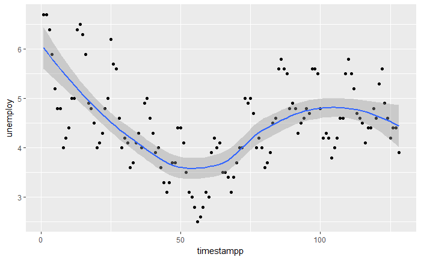

```r
# maine_annual = maine_ts %>% aggregate()/12
# maine_annual
dfr_data = maine_data %>%
  mutate(timestampp = 1:n() )
dfr_data %>% ggplot2::ggplot(ggplot2::aes(x=timestampp, y=unemploy)) +
ggplot2::geom_point() +
ggplot2::geom_smooth()
```

```r
#model
ts_len = dfr_data %>% nrow()
train_frac = 0.8
num_train = (ts_len * train_frac) %>% floor()
num_test = ts_len - num_train
num_test
```

```
[1] 26
```

```r
train_idx = dfr_data[num_train, 'timestampp']
print(train_idx)
```

```
[1] 102
```

```r
dfr_data_new =dfr_data %>%
  mutate(train_test = ifelse(timestampp < train_idx, 'train','test'))
```

```r
# ------------  Holt-Winters
mod_HW$fitted[,1] %>% as.numeric()
```

[output not shown]

```r
dfr_data_new %>% head
```

|  | unemploy | timestampp | train_test |
| --- | --- | --- | --- |
| 1 | 6.7 | 1 | train |
| 2 | 6.7 | 2 | train |
| 3 | 6.4 | 3 | train |
| 4 | 5.9 | 4 | train |
| 5 | 5.2 | 5 | train |
| 6 | 4.8 | 6 | train |

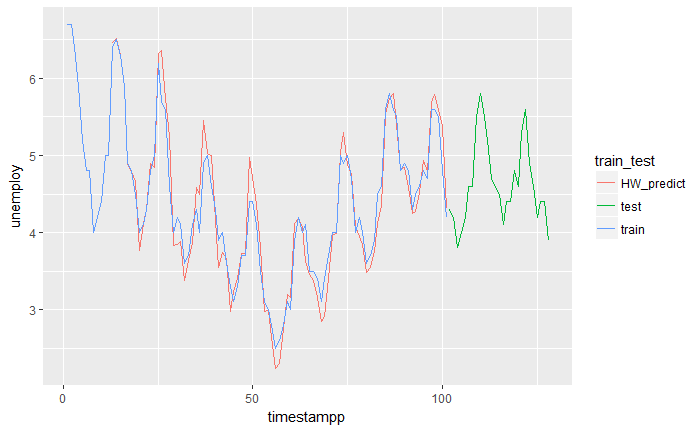

```r
# -------- TRAINING ---------------------------------
#fit HoltWinters - this will fit trend and seasonal
mod_HW =
  dfr_data_new %>%
  dplyr::filter(train_test == 'train') %>%
    select(unemploy) %>%
    ts(start = c(1996,1),freq=12) %>%
    HoltWinters()
#Add HW prediction error back on
#get offset to HW data - there is 'burn in' like a moving average with HW model so have to offset the data
number_training = mod_HW$x %>% nrow
number_HW_fitted = mod_HW$fitted %>% nrow
offset_fitted_data = number_training - number_HW_fitted
#create df with fitted data, correct ts, and labels
dfr_data_pred = dfr_data_new[(offset_fitted_data+1):(train_idx-1),] %>%
  mutate(unemploy = mod_HW$fitted[,1] %>% as.numeric()) %>%
  mutate(train_test = 'HW_predict')
#adding HW fitted data back to data
dfr_data_with_preds = dfr_data_new %>%
  bind_rows(dfr_data_pred)
#plot both training data and HW fitted data
dfr_data_with_preds %>%ggplot(aes(x=timestampp, y=unemploy, colour= train_test)) +
  geom_line()
```

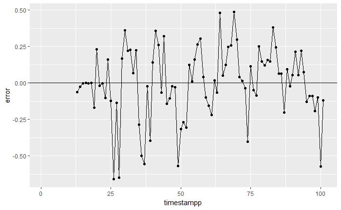

```r
####Error analysis on training data, can we improve model by forecasting error
#calc prediction error
pred_error =   dfr_data_with_preds %>%
  dplyr::filter((train_test == "train") | (train_test == "HW_predict")) %>%
  spread(train_test,unemploy) %>%
  mutate(error = train - HW_predict)
#plot error
pred_error %>% ggplot(aes(x=timestampp, y = error)) +
  geom_point() +
  geom_line() +
  geom_hline(yintercept = 0)
```

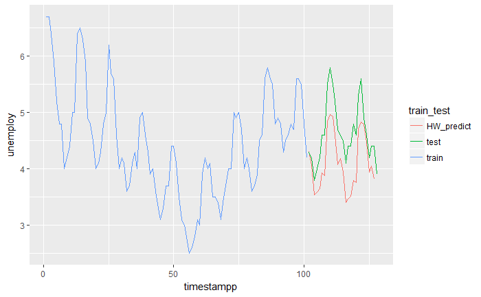

```r
#we want to make n-step ahead forecasts
#we do forecast of determenistic level, trend, season using n-step ahead HW
#we can use ARIMA model to forecast error paths and use these to get confidence intervals
#then check does pred fall in confidence interval
pred = mod_HW %>%
  predict(n.ahead = num_test ) %>%
  as.numeric()
# dfr_data_frame =
dfr_data_pred =  dfr_data_new[(train_idx):(ts_len-1),] %>%
 mutate(unemploy = pred) %>%
 mutate(train_test = 'HW_predict')
dfr_data_with_preds = dfr_data_new %>%
  bind_rows(dfr_data_pred)
dfr_data_with_preds %>%ggplot(aes(x=timestampp, y=unemploy, colour= train_test)) +
  geom_line()
```

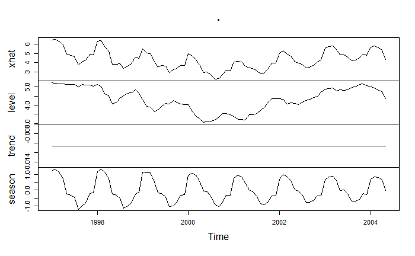

```r
mod_HW$fitted %>% plot
```

```r
#Training ARIMA
model_ARIMA_auto = dfr_data_new %>%
  dplyr::filter(train_test == 'train') %>%
    select(unemploy) %>%
    ts(start = c(1996,1),freq=12) %>%
    auto.arima()
model_ARIMA_auto
```

```
Series: .
ARIMA(0,1,0)(1,0,0)[12]

Coefficients:
        sar1
      0.8447
s.e.  0.0471

sigma^2 estimated as 0.06409:  log likelihood=-11.52
AIC=27.04   AICc=27.16   BIC=32.25
```

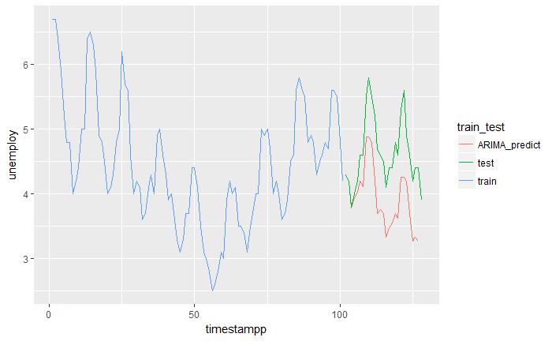

```r
#Forecasting ARIMA
pred = model_ARIMA_auto %>%
  predict(n.ahead = num_test ) %$% #weird operator shorthand for with(.)
  pred %>%
  as.numeric()
# dfr_data_frame =
dfr_data_pred =  dfr_data_new[(train_idx):(ts_len-1),] %>%
 mutate(unemploy = pred) %>%
 mutate(train_test = 'ARIMA_predict')
dfr_data_with_preds = dfr_data_new %>%
  bind_rows(dfr_data_pred)
dfr_data_with_preds %>%ggplot(aes(x=timestampp, y=unemploy, colour= train_test)) +
  geom_line()
```

```r
fit_model = function(model_function, dfr_in, pc_train){

  #model
  ts_len = dfr_data %>% nrow()
  train_frac = 0.8

  num_train = (ts_len * train_frac) %>% floor()

  num_test = ts_len - num_train
  num_test

  train_idx = dfr_data[num_train, 'timestampp']

  dfr_data_new =dfr_data %>%
    mutate(train_test = ifelse(timestampp < train_idx, 'train','test'))

  # ------------  Holt-Winters
  mod_HW$fitted[,1] %>% as.numeric()
  dfr_data_new %>% head


  # -------- TRAINING ---------------------------------

  ##################
  # define model_fit_function(df_train, target_col, prediction_label ,parameters) -> list(model_inner_fitted, dfr_out)
  ##################
  #
  #fit HoltWinters - this will fit trend and seasonal
  mod =
    dfr_data_new %>%
    dplyr::filter(train_test == 'train') %>%
      select(unemploy) %>%
      ts(start = c(1996,1),freq=12) %>%
      HoltWinters()

  #Add HW prediction error back on

  #get offset to HW data - there is 'burn in' like a moving average with HW model so have to offset the data
  number_training = mod_HW$x %>% nrow
  number_HW_fitted = mod_HW$fitted %>% nrow
  offset_fitted_data = number_training - number_HW_fitted

  #create df with fitted data, correct ts, and labels
  dfr_data_pred = dfr_data_new[(offset_fitted_data+1):(train_idx-1),] %>%
    mutate(unemploy = mod_HW$fitted[,1] %>% as.numeric()) %>%
    mutate(train_test = 'HW_predict')


  #adding HW fitted data back to data
  dfr_data_with_preds = dfr_data_new %>%
    bind_rows(dfr_data_pred)

  ##################
  #define model_predict(model, dfr_in, prediction_label, steps_ahead) -> dfr_out
  ##################

    #we do forecast of determenistic level, trend, season using n-step ahead HW
    #we can use ARIMA model to forecast error paths and use these to get confidence intervals
    #then check does pred fall in confidence interval

    pred = mod_HW %>%
      predict(n.ahead = num_test ) %>%
      as.numeric()

    # dfr_data_frame =
    dfr_data_pred =  dfr_data_new[(train_idx):(ts_len-1),] %>%
     mutate(unemploy = pred) %>%
     mutate(train_test = 'HW_predict')

    dfr_data_with_preds = dfr_data_new %>%
      bind_rows(dfr_data_pred)

  output_res = list(model, dfr_out)

  return(model_results)
}
```

Note: Forecasts from both * Holt-Winters * ARIMA(seasonal) Seem to be really sensitive to trend in data The forecasts seem to predict a trend that follows the last few periods of the data. E.g: * If training has upwards direction in trend component near end of data, then forecasts follow that * HW seems less susceptible on a couple of trials

Reasons: * HW fitting routine in R is designed to mimise the one-step ahead errors, maybe we need to minimise multiple steps ahead * auto ARIMA fits in sample data and doesn’t worry about forecasting at all in optimisation precedure, seems a bit wrong

```r
### Holt-Winters Bootstrapping training data

# we can simulate from the error data model to create N more data sets, then re-fit the HW model, to get estimated C.I and mean of parameters

#we can the forecast ahead with each model,use the bootstrapped parameter estimates + simulated ARIMA errors

#then we see how our test data looks vs training

#get error vector
error = pred_error%>%
  drop_na() %>%
  select(error) #%>%
  # as.numeric()

#fit ARIMA to error
model_error_auto = error %>% auto.arima
model_error_auto
model_error = error %>% arima(order= c(1,0,1))
model_error$coef
model_error_auto$fitted
```

[output not shown]

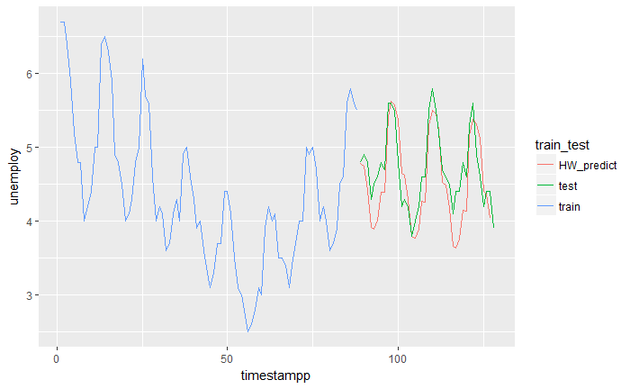

```r
# -------- FORECASTING ---------------------------------
#we want to make n-step ahead forecasts
#we do forecast of determenistic level, trend, season using n-step ahead HW
#we can use ARIMA model to forecast error paths and use these to get confidence intervals
#then check does pred fall in confidence interval
pred = mod_HW %>%
  predict(n.ahead = num_test ) %>%
  as.numeric()
# dfr_data_frame =
dfr_data_pred =  dfr_data_new[(train_idx):(ts_len-1),] %>%
 mutate(unemploy = pred) %>%
 mutate(train_test = 'HW_predict')
dfr_data_with_preds = dfr_data_new %>%
  bind_rows(dfr_data_pred)
dfr_data_with_preds %>%ggplot(aes(x=timestampp, y=unemploy, colour= train_test)) +
  geom_line()
```

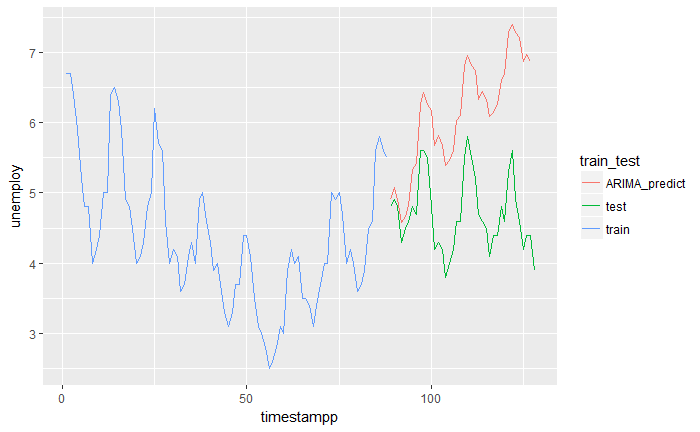

```r
#Forecasting ARIMA
pred = model_ARIMA_auto %>%
  predict(n.ahead = num_test ) %$% #weird operator shorthand for with(.)
  pred %>%
  as.numeric()
# dfr_data_frame =
dfr_data_pred =  dfr_data_new[(train_idx):(ts_len-1),] %>%
 mutate(unemploy = pred) %>%
 mutate(train_test = 'ARIMA_predict')
dfr_data_with_preds = dfr_data_new %>%
  bind_rows(dfr_data_pred)
dfr_data_with_preds %>%ggplot(aes(x=timestampp, y=unemploy, colour= train_test)) +
  geom_line()
```

```r
pred_error =   dfr_data_with_preds %>%
  dplyr::filter((train_test == "test") | (train_test == "HW_predict")) %>%
  spread(train_test,unemploy) %>%
  mutate(error = test - HW_predict)


pred_error %>% ggplot(aes(x=timestampp, y = error)) +
  geom_point() +
  geom_line() +
  geom_hline(yintercept = 0)


#check integration - looks pretty integrated
#plot acf

#Actually check prediction error looks close to train error

error = pred_error%>%
  drop_na() %>%
  # select(error) %>%
  dplyr::pull(error)

error %>% adf.test


error %>% acf #doesn't show integrated

#fit an error model to error in training data




error %>% pacf

library(forecast)
model_error_auto = error %>% auto.arima
model_error = error %>% arima(order= c(1,0,1))
model_error$coef
model_error_auto$fitted


# adf.test(pred_error%>% drop_na())
```

[output not shown]